© Guven

[figure not shown]

# Introduction to Convolutional Neural Networks

One of the most common is the dense layer that connects all units in the layer directly to every unit in the previous layer. By stacking layers, the units in each subsequent layer can represent increasingly sophisticated aspects of the original input, such as learning the simplest Lego pieces at the first layer and then learning the linear combinations of Lego pieces to make up more complex pieces and then eventually learning the large complex structure that the data point(s) represent(s). Recall the error of each layer, which is minimized during training via the backpropagation algorithm.

A Convolutional Neural network CNN is a multiple-layer neural network that consists of convolutional layers, pooling layers, and fully connected layers as hidden layers. In a convolution layer, a filter is slid across the data, and feature maps are extracted through element-wise multiplication. Generally, a convolution layer has multiple filters, where one filter creates one feature map. The role of this layer is **feature extraction**.

The convolution is performed by multiplying the filter pixel-wise with the portion of the image and summing the result. The output is more positive when the portion of the image closely matches the filter and more negative when the portion of the image is the inverse of the filter. Let's move the filter across the entire image, from left to right and top to bottom, recording the convolutional output as we go. We obtain a new array that picks out a particular feature of the input depending on the values in the filter.

This is precisely what a convolutional layer is designed to do, but with multiple filters rather than just one. The example below shows two filters that highlight horizontal and vertical edges.

If we are working with color images, then each filter would have three channels rather than one (i.e., each having shape $3 \times 3 \times 3$) to match the three channels (red, green, blue) of the image.

Note that explainability (XAI) in machine learning refers to understanding and explaining why AI algorithms make their choices, making them transparent and interpretable to humans. A CNN is not more explainable than a regular NN because both are black-box classifiers.

The following example is a $3\times3$ portion of an image (left) convolved by two different filters (right).

$\scriptsize \begin{array}{|r|r|} \hline 0.6 & 0.2 & 0.6 \\ \hline 0.1 & -0.2 & -0.3 \\ \hline -0.5 & -0.1 & -0.3 \\ \hline \end{array} \quad {*} \quad \begin{array}{|r|r|} \hline 1 & 1 & 1 \\ \hline 0 & 0 & 0 \\ \hline -1 & -1 & -1 \\ \hline \end{array} \quad = \quad 2.3$

$\scriptsize \begin{array}{|r|r|} \hline 0.6 & 0.2 & 0.6 \\ \hline 0.1 & -0.2 & -0.3 \\ \hline -0.5 & -0.1 & -0.3 \\ \hline \end{array} \quad {*} \quad \begin{array}{|r|r|} \hline \,\; 1 & \,\; 0 & -1 \\ \hline 1 & 0 & -1 \\ \hline 1 & 0 & -1 \\ \hline \end{array} \quad = \quad 0.2$

The following example is a $4\times4$ portion of an image convolved by the previous filter with a stride of 1 and kernel size of 3 (basically the size of the filter, 3 by 3).

$\scriptsize \begin{array}{|r|r|} \hline 0.1 & 0.6 & 0.2 & 0.6 \\ \hline 0.1 & 0.1 & -0.2 & -0.3 \\ \hline 0.1 & -0.5 & -0.1 & -0.3 \\ \hline 0.1 & 0.1 & -0.1 & -0.1 \\ \hline \end{array} \quad {*} \quad \begin{array}{|r|r|} \hline 1 & 1 & 1 \\ \hline 0 & 0 & 0 \\ \hline -1 & -1 & -1 \\ \hline \end{array} \quad = \quad \begin{array}{|r|r|} \hline 1.4 & 2.3 \\ \hline -0.1 & -0.3 \\ \hline \end{array}$

Note that in PyTorch, `Conv2d` expects an order 4 Tensor, which also has the batch size and channel size. The following code demonstrates the convolution in PyTorch.

Install the module by `pip install soundfile` for audio backend required by `torchaudio`.

```python
%matplotlib inline
import matplotlib.pyplot as plt
plt.rcParams["figure.dpi"] = 72
import numpy as np
import os

from sklearn.model_selection import train_test_split
from sklearn.metrics import accuracy_score

import torch
import torchaudio
import torchaudio.transforms as atransforms
import torchvision
import torchvision.datasets as dset
import torchvision.transforms as vtransforms

# Set the GPU to device 0
gpu = torch.device('cuda:0')

print(f'PyTorch version= {torch.__version__}')
print(f'torchaudio version= {torchaudio.__version__}')
print(f'torchvision version= {torchvision.__version__}')
print(f'CUDA available= {torch.cuda.is_available()}')
```

```
PyTorch version= 2.1.2
torchaudio version= 2.1.2
torchvision version= 0.16.2
CUDA available= True
```

```python
if torch.cuda.is_available():
    # CUDA Installation
    print('CUDA Version')
    !nvcc --version
    print()

    # CUDNN Installation
    print(f'CUDNN Version: {torch.backends.cudnn.version()}')
    print(f'Number of CUDA Devices: {torch.cuda.device_count()}')
    print(f'Active CUDA Device: {torch.cuda.current_device()}')
    print(f'Available devices: {torch.cuda.device_count()}, Name: {torch.cuda.get_device_name(0)}')
    print(f'Current CUDA device: {torch.cuda.current_device()}')
```

```
CUDA Version
nvcc: NVIDIA (R) Cuda compiler driver
Copyright (c) 2005-2022 NVIDIA Corporation
Built on Wed_Jun__8_16:59:34_Pacific_Daylight_Time_2022
Cuda compilation tools, release 11.7, V11.7.99
Build cuda_11.7.r11.7/compiler.31442593_0

CUDNN Version: 8801
Number of CUDA Devices: 1
Active CUDA Device: 0
Available devices: 1, Name: NVIDIA RTX 5000 Ada Generation
Current CUDA device: 0
```

```python
# Portion of the image
x = torch.FloatTensor([[0.6,0.2,0.6],[0.1,-0.2,-0.3],[-0.5,-0.1,-0.3]]).reshape(1,1,3,3)

# A filter
cnn_filter = torch.FloatTensor([[1,1,1],[0,0,0],[-1,-1,-1]]).reshape(1,1,3,3)

# 2D convolution operator
conv = torch.nn.Conv2d(1, 1, 3, bias=False)

# Set the filter weights as above
conv.weight.data = cnn_filter

# Filter
print(conv(x))

# Set the filter weights as above
conv.weight.data = torch.FloatTensor([[1,0,-1],[1,0,-1],[1,0,-1]]).reshape(1,1,3,3)

# Filter
print(conv(x))
```

```
tensor([[[[2.3000]]]], grad_fn=<ConvolutionBackward0>)
tensor([[[[0.2000]]]], grad_fn=<ConvolutionBackward0>)
```

```python
# A larger portion of the image
x = torch.FloatTensor([[0.1,0.6,0.2,0.6],[0.1,0.1,-0.2,-0.3],[0.1,-0.5,-0.1,-0.3],[0.1,0.1,-0.1,-0.1]]).reshape(1,1,4,4)

# Set the filter weights as above
conv.weight.data = cnn_filter

# Filter
print(conv(x))
```

```
tensor([[[[ 1.4000,  2.3000],
          [-0.1000, -0.3000]]]], grad_fn=<ConvolutionBackward0>)
```

PyTorch API:

https://pytorch.org/docs/stable/nn.html

## PyTorch Convolutional Layer

Consider the `Conv2D` layer:

torch.nn.Conv2d(  
in_channels, out_channels, kernel_size, stride=1, padding=0,  
dilation=1, groups=1, bias=True, padding_mode='zeros',  
device=None, dtype=None)

Applies a 2D convolution over an input signal composed of several input planes (such as color planes).  
The output value of the layer with input size $(N,C_{in},H,W)$ and output $(N,C_{out},H_{out},W_{out})$ can be described as:

$\text{out}(N_i,C_{out_j}) = \text{bias}(C_{out_j}) + \sum\limits_{k=0}^{C_{in}-1} \text{weight}(C_{out_j},k) \star \text{input}(N_i,k)$

where $\star$ is a cross-correlation operator, $N$ is the batch size, $C$ is the number of channels, $H$ is the height of the input planes (in pixels) and $W$ is the width (in pixels).

### Conv2D Out Shape

To convert the Conv2D layer to a fully connected layer, the output shape is needed, and it is dependent on the input image size. Computing the shape of the convolutional layer output might be tricky:

$H_{out},W_{out}= \left\lfloor \dfrac{H_{in},W_{in} + 2 \times \text{padding} - \text{dilation}\times(\text{kernel}-1)-1}{\text{stride}} + 1 \right\rfloor$

### Filters

Consider a convolutional filter of `kernel_size=(H,W)` $H \times W$ and a filter depth of $K$ (`filters=K`) where a portion of the input is mapped in 2-dimensions to a single neuron through the filter. If there is more than 1 channel of the image, such as R, G, and B, then these also add as $D$ many dimensions.

$z_{i,j} = \phi \bigg(b + \sum\limits_{l=0}^{k_H-1} \sum\limits_{m=0}^{k_W-1} \sum\limits_{n=0}^{D-1} w_{l,m,n} . x_{i+l,j+m,n} \bigg)$ and $w\in \mathbb{R}^{k_H \times k_W \times D}$ is the weight of the neuron.

### Strides

The `strides` parameter is a 2-tuple of integers, specifying the *step* of the convolution along the x and y-axis of the input volume in *pixels*. Generally, it is left as the default `(1, 1)`, occasionally increased to `(2, 2)` to help reduce the size of the output volume.

### Padding

Padding is necessary to map the input $H \times W$ to the exact dimension of $H \times W$ at the output. $\frac{1}{2}$(`kernel_size`-1), many zeros are necessary on the left, right, top, and bottom boundaries of the input. Consequently, `kernel_size` has to be an odd number.

### Subsampling Layers

A pooling $P$ or subsampling layer after a `Conv2D` layer reduces the spatial size of the representation to reduce the number of parameters (i.e., weights) and computation in the network. Max-pooling layers return only the maximum value at each depth of the pooled area, and average-pooling layers compute the average at each depth of the pooled area. The pooling layer operates on each feature map independently and generally halves each image dimension, e.g., $P_{2 \times 2}$ pooling.

## Example CNN

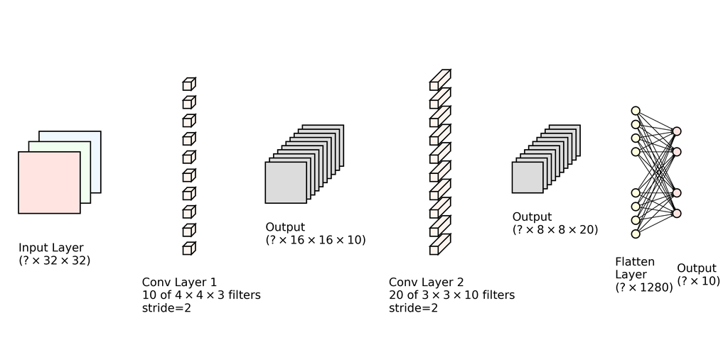

As in the figure, consider a set of input images of size 32x32 with three RGB color channels. The first layer is a `Conv2D` with 10 filters of kernel size (4,4) and a stride of 2. The second layer is a `Conv2D` with 20 filters of kernel size (3,3) and a stride of 2. The `?` is used to show the batch size, and the framework can execute the (Bx32x32x3) tensor all at once. Due to the stride and/or a pooling layer of the same size i.e., (2,2), the size of the data is halved (or more) in both x and y dimensions at the output. The applied filter size is of dimension (4,4,3) at the first layer. Eventually, a flat layer is reached after convolutional layers (using `Flatten()`) and this layer is connected to the output layer with 10 categories to be classified in this example.

## Batch Normalization

One common problem in training a deep neural network is ensuring the weights of the network remain within a reasonable range of values. If they start to become too large, then the gradients will grow (explode), and as errors are propagated backward through the network, the calculation of the gradient in the earlier layers can grow exponentially large, causing wild fluctuations in the weight values. If the loss function starts to return NaN, chances are that weights have grown large enough to cause overflow. This may not happen immediately at the start of the training, but sometimes the network and the loss function can suddenly start returning NaN.

One of the reasons for scaling input data into a neural network is to ensure a stable start to training over the first few iterations. Since the weights of the network are initially randomized, unscaled input could potentially create huge activation values that immediately lead to exploding gradients. For example, instead of passing pixel values from 0 to 255 into the input layer, we usually scale these values to between –1 and 1. Because the input is scaled, it's natural to expect the activations from all future layers to be relatively well-scaled as well. This may be true initially, but as the network trains and the weights move further away from their random initial values, this assumption can start to break down. This phenomenon is known as covariate shift.

Batch normalization drastically reduces this problem. A batch normalization layer calculates the mean and standard deviation of each input channel across the batch and normalizes by subtracting the mean and dividing by the standard deviation. Two learned parameters for each channel are the scale (gamma) and shift (beta). The output is simply the normalized input, scaled by gamma and shifted by beta.

**Input:** Batch $\text{B}=\{x_1, \dots, x_m\}$, learn parameters $\gamma$, $\beta$

**Output:** $y_i=\text{BN}_{\gamma,\beta}(x_i)$

Batch mean,  
$\mu_{B} \leftarrow \frac{1}{m}\sum\limits{i=1}{m}x_i$

Batch variance,  
$\sigma^2_{B} \leftarrow \frac{1}{m}\sum\limits{i=1}{m}(x_i - \mu_B)^2$

Normalize,  
$\hat{x}_i \leftarrow \frac{x_i - \mu_B}{\sqrt{\sigma^2_{B}+\epsilon}}$

Scale and shift,  
$y_i \leftarrow \gamma \hat{x}_i + \beta \equiv \text{BN}_{\gamma,\beta}(x_i)$

Place the batch normalization layers after dense or convolutional layers to normalize the output from those layers. In a way, those layers are connected by small sets of adjustable springs that ensure there aren't any huge shifts in their weights over time.

## A CNN Example on MNIST Dataset

The following example uses MNIST dataset: MNIST database

https://www.kaggle.com/search?q=mnist

Build a deep learning network,

The performance is much better compared to any other previous method.

```python
# Compute H, W for image size 28 - see the nn.Sequential below
def findConv2dOutShape(_H, _W, _conv, _pool=2):
    kernel_size, stride, padding, dilation = _conv.kernel_size, _conv.stride, _conv.padding, _conv.dilation
    H = np.floor((_H+2*padding[0]-dilation[0]*(kernel_size[0]-1)-1)/stride[0]+1)
    W = np.floor((_W+2*padding[1]-dilation[1]*(kernel_size[1]-1)-1)/stride[1]+1)
    if _pool:
        H, W = H/_pool, W/_pool
    return int(H), int(W)

print(findConv2dOutShape(28, 28, torch.nn.Conv2d(1, 16, 5)))
print(findConv2dOutShape(12, 12, torch.nn.Conv2d(16, 32, 5)))
```

```
(12, 12)
(4, 4)
```

```python
# Get the training and testing datasets from a path with resize and normalization
def get_dataloader(_img_size, _bs, _ds, _path):
    train_ds = _ds(
        root=_path, download=False, train=True,
        transform=vtransforms.Compose([
            vtransforms.Resize(_img_size),
            vtransforms.ToTensor(),
            vtransforms.Normalize((0.5,), (0.5,))
        ]))

    # Use pin_memory=True to fix GPU memory
    train_dl = torch.utils.data.DataLoader(train_ds, batch_size=_bs, shuffle=True,
                                           # pin_memory=True,
                                           num_workers=4)

    test_ds = _ds(
        root=_path, download=False, train=False,
        transform=vtransforms.Compose([
            vtransforms.Resize(_img_size),
            vtransforms.ToTensor(),
            vtransforms.Normalize((0.5,), (0.5,))
        ]))

    test_dl = torch.utils.data.DataLoader(test_ds, batch_size=_bs, shuffle=True,
                                          # pin_memory=True,
                                          num_workers=4)

    return train_dl, test_dl

# Requires data files to be under MNIST/raw at the root location
# i.e. /EP_datasets/mnist/MNIST/raw
def get_dl_mnist(_img_size, _bs):
    return get_dataloader(_img_size, _bs, dset.MNIST, '/EP_datasets/mnist')
```

```python
IMG_SIZE = 28
IMG_CHANNEL= 1  # color channel

MLP_HIDDEN= 16  # Hidden layer size

LAST_LINEAR_SIZE = 1024  # 1024 is arbitrary
N_CLASSES = 10  # output layer size

BATCH_SIZE = 5000

class PyTorchCNN(torch.nn.Module):
    def __init__(self, epochs=10, eta=0.001, batch_size=1000, seed=0):
        super().__init__()
        self.random = np.random.RandomState(seed)  # shuffle mini batches
        self.epochs = epochs  # number of iterations
        self.eta = eta  # learning rate
        self.batch_size = batch_size  # size of training batch - 1 would not work
        self.loss_func = torch.nn.CrossEntropyLoss()
        self.model = None

    def init_layers(self, _K):
        import torch.nn as nn
        self.model = nn.Sequential(
            # Conv -> (?, IMG_SIZE, IMG_SIZE, MLP_HIDDEN)
            # Pool -> (?, IMG_SIZE/2, IMG_SIZE/2, MLP_HIDDEN)
            nn.Conv2d(IMG_CHANNEL, MLP_HIDDEN, 5),
            nn.ReLU(inplace=True),
            nn.MaxPool2d(2),
            nn.BatchNorm2d(MLP_HIDDEN),

            nn.Conv2d(MLP_HIDDEN, MLP_HIDDEN*2, 5),
            nn.ReLU(inplace=True),
            nn.MaxPool2d(2),

            nn.Flatten(start_dim=1),

            # 4*4 is computed in the above cell - findConv2dOutShape
            nn.Linear(MLP_HIDDEN*2 * 4*4, LAST_LINEAR_SIZE),
            nn.BatchNorm1d(LAST_LINEAR_SIZE),

            nn.Linear(LAST_LINEAR_SIZE, _K),
        ).to(gpu)

    def predict(self, _X):
        _X = torch.FloatTensor(_X).to(gpu, non_blocking=True)
        assert self.model is not None
        with torch.no_grad():
            logits = self.model(_X)
        ypred = torch.argmax(logits, dim=1)
        return ypred.cpu().numpy()

    def fit(self, _train_dl, info=False):
        import sys
        self.init_layers(N_CLASSES)

        optimizer = torch.optim.Rprop(self.model.parameters(), lr=self.eta)

        for e in range(self.epochs):
            for data in _train_dl:
                X, y = data[0].to(gpu), data[1].to(gpu)

                optimizer.zero_grad()
                net_out = self.model(X)
                loss = self.loss_func(net_out, y)
                loss.backward()
                optimizer.step()

            if info:
                with torch.no_grad():
                    acc = accuracy_score(data[1].tolist(), np.argmax(self.model(X).cpu(), axis=1).tolist())
                sys.stderr.write(f"\r{e+1:02d}/{self.epochs:02d} | Loss: {loss:<6.2f} | Tr Acc: {acc*100:3.2f}%")
                sys.stderr.flush()
```

```python
cnn = PyTorchCNN(epochs=7, eta=0.001, batch_size=BATCH_SIZE).to(gpu)

# example - the fit function will override the NN configuration
cnn.init_layers(N_CLASSES)
print(cnn)
```

```
PyTorchCNN(
  (loss_func): CrossEntropyLoss()
  (model): Sequential(
    (0): Conv2d(1, 16, kernel_size=(5, 5), stride=(1, 1))
    (1): ReLU(inplace=True)
    (2): MaxPool2d(kernel_size=2, stride=2, padding=0, dilation=1, ceil_mode=False)
    (3): BatchNorm2d(16, eps=1e-05, momentum=0.1, affine=True, track_running_stats=True)
    (4): Conv2d(16, 32, kernel_size=(5, 5), stride=(1, 1))
    (5): ReLU(inplace=True)
    (6): MaxPool2d(kernel_size=2, stride=2, padding=0, dilation=1, ceil_mode=False)
    (7): Flatten(start_dim=1, end_dim=-1)
    (8): Linear(in_features=512, out_features=1024, bias=True)
    (9): BatchNorm1d(1024, eps=1e-05, momentum=0.1, affine=True, track_running_stats=True)
    (10): Linear(in_features=1024, out_features=10, bias=True)
  )
)
```

```python
%%time

# Get the dataset
dl_train, dl_test = get_dl_mnist(IMG_SIZE, BATCH_SIZE)

cnn.fit(dl_train, info=True)
```

```
07/07 | Loss: 0.05   | Tr Acc: 98.64%
```

```
CPU times: total: 3.61 s
Wall time: 23.1 s
```

```python
# Test performance
y_test, y_pred = [], []
for dt in dl_test:
    X = dt[0]
    y_test += dt[1].tolist()

    with torch.no_grad():
        y_pred += cnn.predict(X).tolist()

accuracy_score(y_test, y_pred)
```

```
0.9843
```

## Audio Signal Classification

Recurrent neural networks can model sequences such as audio or text. However, audio or time-series data can be modeled by frequency domain representations as well.

The following Kaggle dataset has audio files in WAV format, which can be read by the `torchaudio` backend, `soundfile` library. The dataset is composed,

- class 'cat' with 164 WAV files, 1323 sec of total audio
- class 'dog' with 113 WAV files, 598 sec of total audio

The classical approach to modeling audio is based on Fourier transform and the spectrogram of audio or time-series signal. A spectrogram is revealed as an image with time as the x-axis and frequency information as the y-axis. While the details are skipped, the following Cells demonstrate the processing of one-dimensional digital audio sequences into two-dimensional spectrogram images. The hop-on time axis is set by `FFT_HOP_N`, and it corresponds to 100 msecs since the sampling frequency is 2KHz or 2000. As a result, 10 data points are extracted for 1 sec of audio. The number of frequency bins is selected as 20 with the parameter `MFCC_M`. As a result, a strip of 20 values per time slot (100 msecs) is generated during feature extraction.

```python
PATH_DATA = '/EP_datasets/cats_dogs/'

# Number of features, frequency bins
MFCC_M = 20

# 2000 samples / sec
SAMPLING_FRQ = 2000
FFT_HOP_N = 200

x, sr = torchaudio.load(PATH_DATA+'cat_10.wav', normalize=True)
Tr_resampler = atransforms.Resample(sr, SAMPLING_FRQ)
x = Tr_resampler(x)
Tr_mfcc = atransforms.MFCC(sample_rate=SAMPLING_FRQ, n_mfcc=MFCC_M,
                           melkwargs={'n_fft':512, 'hop_length':FFT_HOP_N, 'n_mels':23, 'center':False})
mfccs = Tr_mfcc(x)
```

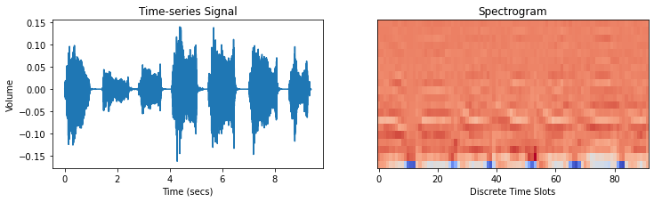

```
#features, #data points= (20, 92)
```

```python
# Plot signal and MFCC features
_, ax = plt.subplots(1, 2, figsize=(12,3), dpi=72)
y1 = x.reshape((-1,)).numpy()
ax[0].plot(np.arange(len(y1))/SAMPLING_FRQ, y1)
ax[0].set_xlabel('Time (secs)')
ax[0].set_ylabel('Volume')
ax[0].set_title('Time-series Signal')

# Display the spectrogram
y2 = mfccs.reshape((MFCC_M,-1)).numpy()
ax[1].imshow(y2, origin='lower', cmap='coolwarm', interpolation='nearest', aspect='auto')
ax[1].set_xlabel('Discrete Time Slots')
ax[1].get_yaxis().set_visible(False)
ax[1].set_ylabel('Mel Scale')
ax[1].set_title('Spectrogram')
plt.show()

# Sanity
print(f'#features, #data points= {y2.shape}')
```

```python
# check signal durations
Flist = [f for f in os.listdir(PATH_DATA) if f.lower().endswith('.wav')]
print(f'#Files= {len(Flist)}')

Sxx = []
for fn in Flist:
    x, sr = torchaudio.load(os.path.join(PATH_DATA, fn), normalize=True)
    # Category
    ct = 'cat' if 'cat' in fn else 'dog'
    # signal duration and the category of the signal
    Sxx += [(len(x.reshape((-1,)).numpy())/sr, ct)]
```

```
#Files= 277
```

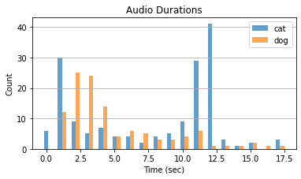

```python
# plot durations
d_cat = [_[0] for _ in Sxx if _[1] == 'cat']
d_dog = [_[0] for _ in Sxx if _[1] == 'dog']
d_bins = int(max(max(d_cat), max(d_dog))) + 1
h_cat = np.histogram(d_cat, bins=d_bins, range=(0,d_bins))
h_dog = np.histogram(d_dog, bins=d_bins, range=(0,d_bins))
plt.figure(figsize=(6,3), dpi=72)
plt.bar(h_cat[1][:-1], h_cat[0], width=0.3, label='cat', alpha=0.7)
plt.bar(np.array(h_dog[1][:-1])+0.3, h_dog[0], width=0.3, label='dog', alpha=0.7)
plt.grid(axis='y')
plt.xlabel('Time (sec)')
plt.ylabel('Count')
plt.title('Audio Durations')
plt.legend()
plt.show()
```

```python
MFCC_N = 10*SAMPLING_FRQ//FFT_HOP_N  # cut it at 10 seconds or top up to 10 seconds by repeating circularly

# copy spectrogram vertical strips to extend the data point to size (20,100)
def topup(_X):
    __X = _X.copy()
    while _X.shape[1] < MFCC_N:
        _X = np.concatenate((_X, __X), axis=1)
    if _X.shape[1] > MFCC_N:
        _X = _X[:,:MFCC_N]
    return _X

Sxx = []
for fn in Flist:
    x, sr = torchaudio.load(os.path.join(PATH_DATA, fn), normalize=True)
    x = Tr_mfcc(Tr_resampler(x)).reshape((MFCC_M,-1)).numpy()
    if x.shape[1] > MFCC_N:
        x = x[:,:MFCC_N]
    elif x.shape[1] < MFCC_N:
        x = topup(x)
    ct = 'cat' if 'cat' in fn else 'dog'
    Sxx += [(x, ct)]
```

```python
# might require even number sizes with the batches
X = np.array([_[0] for _ in Sxx]).reshape((-1,1,MFCC_M,MFCC_N))
y = np.array([0 if _[1]=='cat' else 1 for _ in Sxx], dtype='int64')

X_tr, X_ts, y_tr, y_ts = train_test_split(X, y, random_state=0, test_size=0.50)

# sanity
print(X.shape, y.shape, X_tr.shape, y_tr.shape, X_ts.shape, y_ts.shape)
```

```
(277, 1, 20, 100) (277,) (138, 1, 20, 100) (138,) (139, 1, 20, 100) (139,)
```

```python
# use/create a dataloader
def get_dataloader_audio(_X_tr, _X_ts, _y_tr, _y_ts, _bs):
    dataset_tr = torch.utils.data.TensorDataset(torch.tensor(_X_tr), torch.tensor(_y_tr))
    dataloader_tr = torch.utils.data.DataLoader(dataset_tr,
                                                sampler=torch.utils.data.RandomSampler(dataset_tr), batch_size=_bs)
    dataset_ts = torch.utils.data.TensorDataset(torch.tensor(_X_ts), torch.tensor(_y_ts))
    dataloader_ts = torch.utils.data.DataLoader(dataset_ts, batch_size=_bs)
    return dataloader_tr, dataloader_ts

dla_train, dla_test = get_dataloader_audio(X_tr, X_ts, y_tr, y_ts, BATCH_SIZE)
```

```python
# compute Conv sizes - use below
print(findConv2dOutShape(MFCC_M, MFCC_N, torch.nn.Conv2d(1, 8, 5)))
print(findConv2dOutShape(8, 48, torch.nn.Conv2d(8, 16, 5)))
```

```
(8, 48)
(2, 22)
```

```python
MLP_HIDDEN= 8  # Hidden layer size

LAST_LINEAR_SIZE= 32
N_CLASSES= 2  # output layer size

BATCH_SIZE= 50

class PyTorchCNN2(PyTorchCNN):
    def __init__(self, epochs=10, eta=0.001):
        super().__init__(epochs=epochs, eta=eta)
        self.epochs = epochs  # number of iterations
        self.eta = eta  # learning rate
        self.loss_func = torch.nn.CrossEntropyLoss()
        self.model = None

    def init_layers(self, _K):
        import torch.nn as nn
        self.model = nn.Sequential(
            nn.Conv2d(1, MLP_HIDDEN, 5),
            nn.ReLU(inplace=True),
            nn.MaxPool2d(2),
            nn.BatchNorm2d(MLP_HIDDEN),

            nn.Conv2d(MLP_HIDDEN, MLP_HIDDEN*2, 5),
            nn.ReLU(inplace=True),
            nn.MaxPool2d(2),

            nn.Flatten(start_dim=1),

            # 2*22 is computed in the above cell - findConv2dOutShape
            nn.Linear(MLP_HIDDEN*2 * 2*22, LAST_LINEAR_SIZE),
            nn.BatchNorm1d(LAST_LINEAR_SIZE),

            nn.Linear(LAST_LINEAR_SIZE, _K),
            nn.Tanh()
        ).to(gpu)
```

```python
cnn2 = PyTorchCNN2(epochs=100, eta=0.005).to(gpu)

# example - the fit function will override the NN configuration
cnn2.init_layers(N_CLASSES)
print(cnn2)
```

```
PyTorchCNN2(
  (loss_func): CrossEntropyLoss()
  (model): Sequential(
    (0): Conv2d(1, 8, kernel_size=(5, 5), stride=(1, 1))
    (1): ReLU(inplace=True)
    (2): MaxPool2d(kernel_size=2, stride=2, padding=0, dilation=1, ceil_mode=False)
    (3): BatchNorm2d(8, eps=1e-05, momentum=0.1, affine=True, track_running_stats=True)
    (4): Conv2d(8, 16, kernel_size=(5, 5), stride=(1, 1))
    (5): ReLU(inplace=True)
    (6): MaxPool2d(kernel_size=2, stride=2, padding=0, dilation=1, ceil_mode=False)
    (7): Flatten(start_dim=1, end_dim=-1)
    (8): Linear(in_features=704, out_features=32, bias=True)
    (9): BatchNorm1d(32, eps=1e-05, momentum=0.1, affine=True, track_running_stats=True)
    (10): Linear(in_features=32, out_features=2, bias=True)
    (11): Tanh()
  )
)
```

```python
%%time

cnn2.fit(dla_train, info=True)
```

```
100/100 | Loss: 0.13   | Tr Acc: 100.00%
```

```
CPU times: total: 359 ms
Wall time: 356 ms
```

```python
# 50-50 train-test
def predict_dla(_clf, _dla_test):
    test, pred = [], []
    for data in _dla_test:
        test += data[1].tolist()
        with torch.no_grad():
            pred += _clf.predict(data[0]).tolist()
    return accuracy_score(test, pred)

print(f'{predict_dla(cnn2, dla_test):.3f}')
```

```
0.878
```

```python
# create a dataloader for every fold - inefficient
def kfold_eval(_clf, _X, _y):
    from sklearn.model_selection import StratifiedKFold
    accuracies = []
    kf = StratifiedKFold(n_splits=10, shuffle=True, random_state=0)
    for train_ix, test_ix in kf.split(_X, _y):
        dla_tr, dla_ts = get_dataloader_audio(_X[train_ix], _X[test_ix], _y[train_ix], _y[test_ix], BATCH_SIZE)
        _clf.fit(dla_tr)
        accuracies += [predict_dla(_clf, dla_ts)]
    return np.array(accuracies)
```

```python
# 10-fold CV
Acc = kfold_eval(cnn2, X, y)

print(f'10-fold CV Acc= {np.mean(Acc):.2f} {chr(177)}{np.std(Acc):.3f}')
```

```
10-fold CV Acc= 0.88 ±0.096
```

## References

1. Krizhevsky, Alex, Ilya Sutskever, and Geoffrey E. Hinton. "Imagenet classification with deep convolutional neural networks." Advances in neural information processing systems 25 (2012): 1097-1105.
2. TorchAudio Documentation. https://pytorch.org/audio/stable/index.html. Accessed May 2023.
3. PyTorch GitHub. https://github.com/pytorch. Accessed Oct 2023.

## Exercises

**Exercise 1.** Add dropout layers to both MNIST classifier and Audio classifier neural networks.

**Exercise 2.** Change the duration cut to 5 seconds and 20 seconds. Compare performances.

```python
%%html
<style>
    table {margin-left: 0 !important;}
    p {font-family: verdana;}
    li {font-family: verdana;}
    div {font-size: 10pt;}
</style>
<!-- Display markdown tables left oriented in this notebook. -->
```